# da-ws-03-2

Maite Lezama Valdes, Lukas Ditzel, Jannis Gottwald, Alexander Jorns, Michaela Vorndran

5 November 2016

## Look and learn

### da-ws-03-1

```r
setwd("E:/16_11_1_DA")
df<-read.table("hessen_holzeinschlag_1997-2014.csv", skip = 4, header=T, sep=";", dec =",")
class(df)
```

```
## [1] "data.frame"
```

```r
# data frame ohne Zeile 19
df<-df[-19, ]
df
```

```
##     FWJ Eiche Buche Buntholz Fichte Kiefer Insgesamt
## 1  1997   155  1036       21   1684    779      3675
## 2  1998   265  1631       36   1761    951      4644
## 3  1999   278  1796       32   1732    914      4752
## 4  2000   204  1300        0   1024    616      3144
## 5  2001   322  1515        0   1592    706      4135
## 6  2002   265  1410        0   2036    663      4374
## 7  2003   404  1698        0   2482    820      5404
## 8  2004   400  1572        0   2775    757      5504
## 9  2005   370  1489        0   2601    887      5347
## 10 2006   388  1881        0   2580    844      5693
## 11 2007   271  1816        0   6524    782      9393
## 12 2008   292  1721        0   3698    661      6372
## 13 2009   135  1149        0   1926    534      3744
## 14 2010   223  1733        0   3201    807      5964
## 15 2011   297  1908        0   2018    829      5052
## 16 2012   281  1821        0   1685    777      4564
## 17 2013   284  1821        0   1721    813      4639
## 18 2014   285  1911        0   1704    805      4705
```

```r
summary (df)
```

```
##       FWJ         Eiche           Buche         Buntholz
##  1997   : 1   Min.   :135.0   Min.   :1036   Min.   : 0.000
##  1998   : 1   1st Qu.:265.0   1st Qu.:1496   1st Qu.: 0.000
##  1999   : 1   Median :282.5   Median :1710   Median : 0.000
##  2000   : 1   Mean   :284.4   Mean   :1623   Mean   : 4.944
##  2001   : 1   3rd Qu.:315.8   3rd Qu.:1820   3rd Qu.: 0.000
##  2002   : 1   Max.   :404.0   Max.   :1911   Max.   :36.000
##  (Other):12
##      Fichte         Kiefer        Insgesamt
##  Min.   :1024   Min.   :534.0   Min.   :3144
##  1st Qu.:1708   1st Qu.:718.8   1st Qu.:4422
##  Median :1972   Median :793.5   Median :4728
##  Mean   :2375   Mean   :774.7   Mean   :5061
##  3rd Qu.:2596   3rd Qu.:826.8   3rd Qu.:5479
##  Max.   :6524   Max.   :951.0   Max.   :9393
##
```

```r
write.table(df, "hessen_holzeinschlag_1997-2014_clean.csv", dec=".", sep=",")
```

### da-ws-03-2

#### 1:

##### Create a simple visualization which gives a quick, temporally non explicit and descriptive statistical overview of the harvest by tree type and as a total over all trees (i.e. a similar kind of information the `summary` function provides).

```r
summary (df)
```

```
##       FWJ         Eiche           Buche         Buntholz
##  1997   : 1   Min.   :135.0   Min.   :1036   Min.   : 0.000
##  1998   : 1   1st Qu.:265.0   1st Qu.:1496   1st Qu.: 0.000
##  1999   : 1   Median :282.5   Median :1710   Median : 0.000
##  2000   : 1   Mean   :284.4   Mean   :1623   Mean   : 4.944
##  2001   : 1   3rd Qu.:315.8   3rd Qu.:1820   3rd Qu.: 0.000
##  2002   : 1   Max.   :404.0   Max.   :1911   Max.   :36.000
##  (Other):12
##      Fichte         Kiefer        Insgesamt
##  Min.   :1024   Min.   :534.0   Min.   :3144
##  1st Qu.:1708   1st Qu.:718.8   1st Qu.:4422
##  Median :1972   Median :793.5   Median :4728
##  Mean   :2375   Mean   :774.7   Mean   :5061
##  3rd Qu.:2596   3rd Qu.:826.8   3rd Qu.:5479
##  Max.   :6524   Max.   :951.0   Max.   :9393
##
```

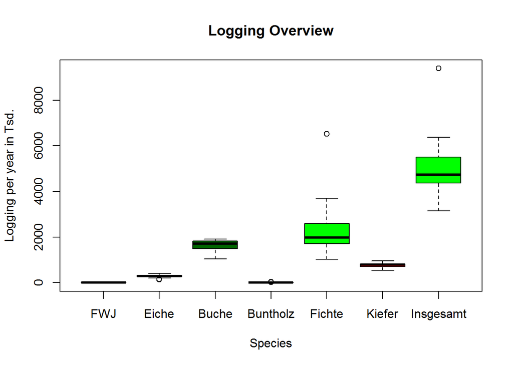

```r
df1 <- df
df2 <- df
attach(df2)

box<-boxplot(df1, xlab="Species",
ylab="Logging per year in Tsd.", main= "Logging Overview", names = colnames(df1),
col = (c("green", "green","darkgreen", "darkgreen", "green", "red")))
```

#### 2:

##### Have a look at beech and spruce and write exactly one sentence for each of the tree species which summarizes what you see.

The interquartil range of Beech harvest is relatively small lying between 1500 and 1800, the distribution being left skewed. In comparison spruce shows a higher variation in quantities harvested, interquartil range of the right-skewed distribution lies between about 1700 and 2600 with an outlier at about 6500.

#### 3:

##### Create another visualization which - in the same figure panel - shows how each beech harvest over the time span is related each of the oak, pine, spruce and colored wood harvests in a 2 by 2 grid (i.e. arrange the figures in a 2 columns and 2 rows layout).

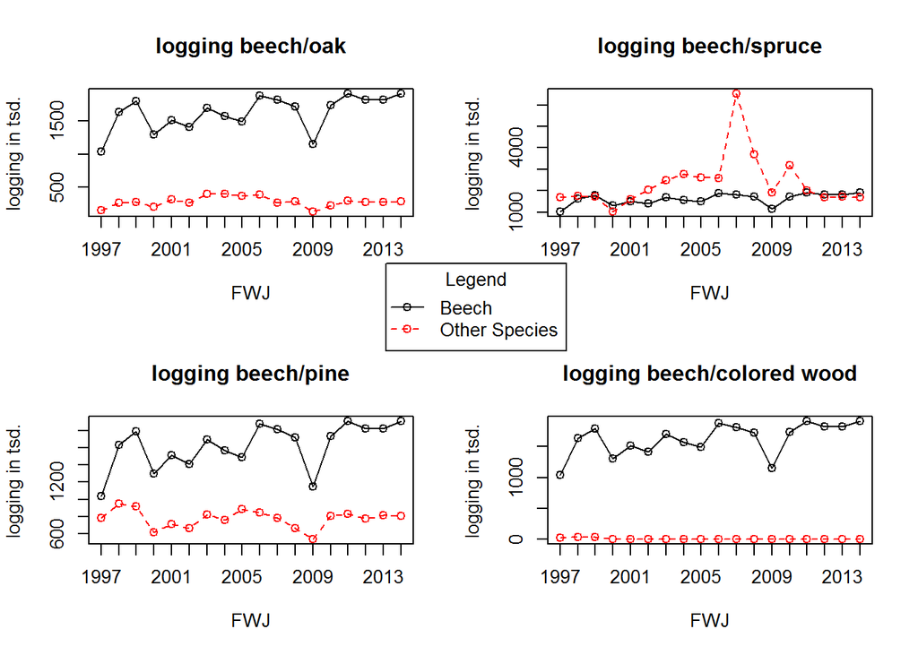

```r
be<- cbind(Buche,Eiche)
bf<- cbind(Buche, Fichte)
bk <-cbind(Buche, Kiefer)
bb <-cbind(Buche, Buntholz)
par(mfrow=c(2,2), xpd=NA)
matplot (FWJ, be, type ="o", pch=1, main = "logging beech/oak", ylab = "logging in tsd.",xaxt="n")
axis(1, at=c(1997:2014))
matplot (FWJ, bf,type ="o", pch=1, main="logging beech/spruce",ylab = "logging in tsd.", xaxt="n")
axis(1, at=c(1997:2014))
matplot (FWJ, bk, type ="o", pch=1, main="logging beech/pine",ylab = "logging in tsd.", xaxt="n")
axis(1, at=c(1997:2014))
matplot (FWJ, bb, type ="o", pch=1, main= "logging beech/colored wood",ylab = "logging in tsd.",xaxt="n")
axis(1, at=c(1997:2014))
legend("topleft", inset=c(-0.5,-1.2), legend = c("Beech","Other Species"), horiz=F, col=1:2, pch=1, title= "Legend", lty = c(1,2))
```

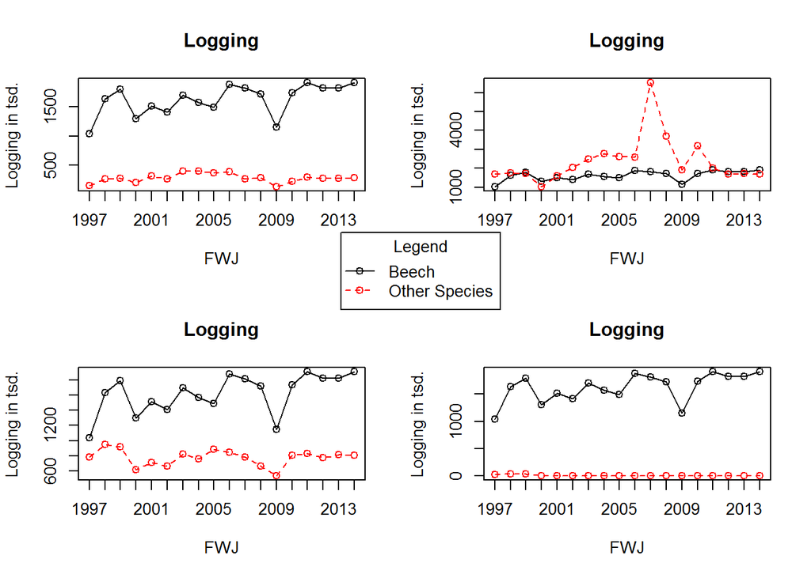

```r
#or

l<- list(be, bf, bk, bb)
for (i in l) {matplot (FWJ, i, type ="o", pch=1, main= "Logging", ylab = "Logging in tsd.",xaxt="n")
  axis(1, at=c(1997:2014))}
legend("topleft", inset=c(-.5,-1.2), legend = c("Beech","Other Species"), horiz=F, col=1:2, pch=1, title= "Legend", lty = c(1,2))
```